# Moretz Brandon, Programming with R Assignment #1

05 November, 2018

### Test Items

Read each question carefully and address each element. Do not output contents of vectors or data frames unless requested.

## 1.) Vector Manipulations

(4 points) This problem deals with vector manipulations.

### a.) Concatenation

Create a vector that contains the following, in this order, and **output the final, resulting vector**.

**Do not round any values, unless requested.**

- A sequence of integers from 0 to 4, inclusive.
- The number 13
- Three repetitions of the vector c(2, -5.1, -23).
- The arithmetic sum of 7/42, 3 and 35/42

```r
# Note: Parenthesis are not required in the final element. They are included for readability.
values <- c(seq(from = 0, to = 4), 13, rep(c(2, -5.1, -23), 3), (7 / 42) + 3 + (35 / 42))

display_vector(values)
```

*0*, *1*, *2*, *3*, *4*, *13*, *2*, *-5.1*, *-23*, *2*, *-5.1*, *-23*, *2*, *-5.1*, *-23* and *4*

### b.) Sorting

- Sort the vector created in **(1)(a)** in ascending order. **Output this result**.
- Determine the length of the resulting vector and assign to “L”. **Output L**.
- Generate a descending sequence starting with L and ending with 1.
- Add this descending sequence arithmetically the sorted vector. This is **vector addition**, *not vector combination*. **Output the contents**.

*Do not round any values.*

```r
values.sorted <- sort(values, decreasing = F)

display_vector(values.sorted)
```

*-23*, *-23*, *-23*, *-5.1*, *-5.1*, *-5.1*, *0*, *1*, *2*, *2*, *2*, *2*, *3*, *4*, *4* and *13*

```r
L <- length(values.sorted)

display_vector(L)
```

*16*

```r
values.desc <- seq(from = L, to = 1)

result <- values.desc + values.sorted

display_vector(result)
```

*-7*, *-8*, *-9*, *7.9*, *6.9*, *5.9*, *10*, *10*, *10*, *9*, *8*, *7*, *7*, *7*, *6* and *14*

### c.) Subsetting

- Extract the first and last elements of the vector you have created in **(1)(b)** to form another vector with the extracted elements.
- Form a third vector from the elements not extracted.
- **Output these vectors**.

```r
result.fl <- c(first(result), last(result))

display_vector(result.fl)
```

*-7* and *14*

```r
result.exc <- result[-which(result %in% result.fl)]

display_vector(result.exc)
```

*-8*, *-9*, *7.9*, *6.9*, *5.9*, *10*, *10*, *10*, *9*, *8*, *7*, *7*, *7* and *6*

### d.) Reconstruction

- Use the vectors from **(c)** to reconstruct the vector in **(b)**.
- **Output this vector**.
- Sum the elements and round to two decimal places.

```r
result.d <- c(result.fl[1], result.exc, result.fl[2])

stopifnot(all.equal(result,result.d))

display_vector(result.d)
```

*-7*, *-8*, *-9*, *7.9*, *6.9*, *5.9*, *10*, *10*, *10*, *9*, *8*, *7*, *7*, *7*, *6* and *14*

```r
display_vector(round(sum(result.d), 2))
```

*84.7*

## 2.) Trigonometric Function

(5 points) The expression y = sin(x/2) + cos(x/2) is a trigonometric function.

### a.) User-Defined Function

Create a user-defined function - via *function()* - that implements the trigonometric function above, accepts numeric values, “x,” calculates and returns values “y.”

```r
trig_fun <- function(x) {
    sin(x/2) + cos(x/2)
}
```

### b.) Logical Subset

**Do not use packages or programs you may find on the internet or elsewhere.**

**Do not output the other elements of the vectors x and y.**

Use coding methods shown in the *Quick Start Guide for R*.

```r
x <- seq(from = -2, to = 2, length.out = 4001)
y <- trig_fun(x)

max_y <- max(y)
x_val <- x[y == max_y]

stopifnot( trig_fun(x_val) == max_y )

display_vector(round(c(x_val, max_y), digits = 3))
```

*1.571* and *1.414*

### c.) Visualization

- Plot y versus x in color, with x on the horizontal axis.
- Show the location of the **maximum** value of y determined in **2(b)**.
- Show the values of x and y corresponding to the **maximum** value of y in the display.
- Add a title and other features such as text annotations.

*Text annotations may be added via *text()* for base R plots and *geom_text()* or *geom_label()* for ggplots.*

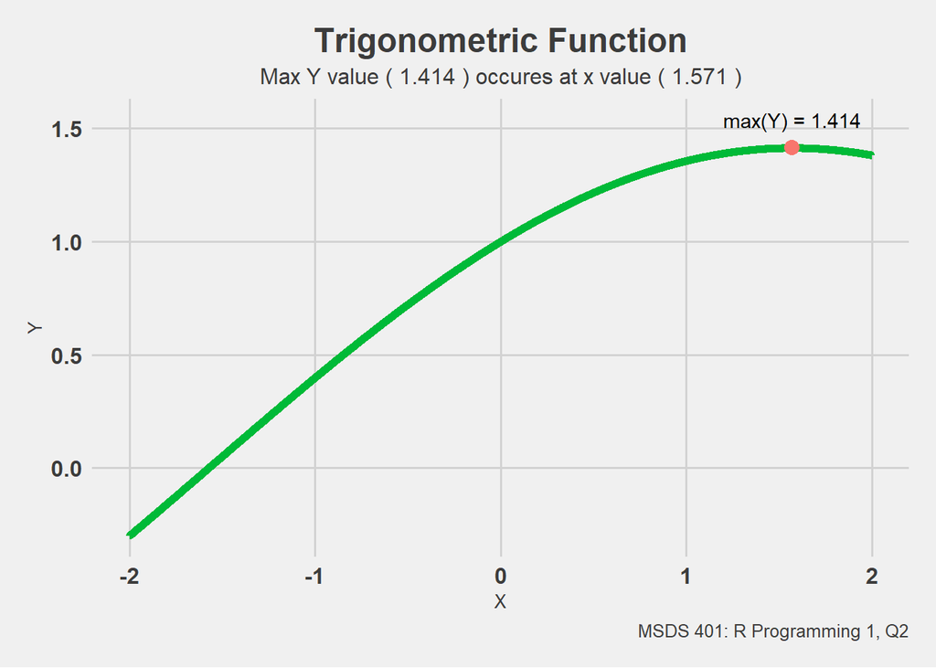

```r
trig.data <- data.table(x,y)

offset <- .125

ggplot(trig.data, aes(x, y), label = "f(x)", show.legend = T) +
    geom_line(color = "#00ba38", lwd = 2) +
    geom_point(aes(x_val, max_y), color = "#f8766d", size = 3.5) +
    annotate("text", x = x_val, y = max_y + offset, label = paste("max(Y) =", round(max_y,3 ))) +
    labs(title = "Trigonometric Function",
       subtitle = paste("Max Y value (", round(max_y, 3), ") occures at x value (", round(x_val, 3), ")"),
       caption = "MSDS 401: R Programming 1, Q2", x = "X", y = "Y")
```

## 3.) Function Intersection

*(4 points)* This problem requires finding the point of intersection of two functions. Using the function `y = cos(x/2)*sin(x/2)`,

- find where the curved line `y = -(x/2)**3` intersects it within the range of values used in part (2) *(i.e. 4001 equally-spaced values from -2 to 2)*.
- Plot both functions on the same display, and show the point of intersection.
- Present the coordinates of this point as text in the display.

NOTE: the functions to implement are enclosed in backticks. Ignore the backticks when implementing in code.

- Plot both functions on the same display, and show the point of intersection.
- Present the coordinates of this point as text in the display.

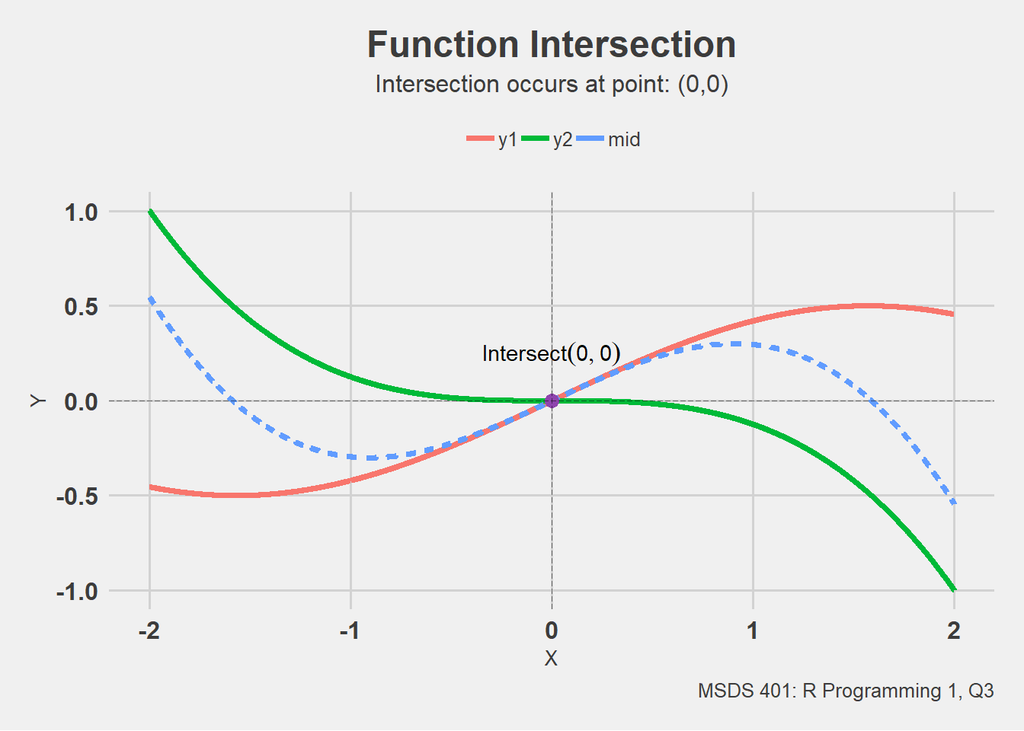

```r
f1 <- function(x) {
    cos(x / 2) * sin(x / 2)
}

f2 <- function(x) {
    -(x / 2) ** 3
}

fun.values <- melt(data.table(x, y1 <- f1(x), y2 <- f2(x),
   mid <- y2 + y1)[,
        .(x, y1, y2, mid)], id = "x")


offset <- .25

fun.values$Type <- ifelse(fun.values$variable == 'mid', 'solid', 'dotdash')

fun.intercept <- fun.values[variable == "mid" & value == 0,][, .(x, y = value)]

ggplot(fun.values, aes(x = x, y = value, color = variable, linetype = Type, group = as.factor(variable))) +
    geom_line(lwd = 1.4) +
    geom_point(aes(x = fun.intercept$x, y = fun.intercept$y), size = 3, color = "#8E44AD", alpha = .8) +

    # These two lines also mark the intersection.
    geom_vline(xintercept = fun.intercept$x, linetype = 'longdash', alpha = .5, lwd = .25) +
    geom_hline(yintercept = fun.intercept$y, linetype = 'longdash', alpha = .5, lwd = .25) +

    # I think this looks better with text in the title area only, with the following line commented out.
    # but wanted to make sure I followed instructions.
    annotate("text", x = fun.intercept$x, y = fun.intercept$y + offset, parse = TRUE, label = paste0("Intersect (", fun.intercept$x, ",", fun.intercept$y, ")")) +
    scale_linetype(guide = 'none') +
    labs(title = "Function Intersection",
       subtitle = paste0("Intersection occurs at point: (", fun.intercept$x, ",", fun.intercept$y, ")"),
       caption = "MSDS 401: R Programming 1, Q3", x = "X", y = "Y")
```

## 4.) Trees

(6 points) Use the “trees” dataset for the following items.

*This dataset has three variables (Girth, Height, Volume) on 31 felled black cherry trees.*

### a.) Dataset

- Use *data(trees)* to load the dataset.
- Check and output the structure with *str()*.
- Use *apply()* to return the median values for the three variables. **Output these values**.
- Using R and logicals, output the row number and the three measurements - Girth, Height and Volume - of any trees with Girth equal to median Girth.

*It is possible to accomplish this last request with one line of code.*

```r
# same as data(trees)
trees <- as.data.table(trees)

str(trees)
```

```
## Classes 'data.table' and 'data.frame':   31 obs. of  3 variables:
##  $ Girth : num  8.3 8.6 8.8 10.5 10.7 10.8 11 11 11.1 11.2 ...
##  $ Height: num  70 65 63 72 81 83 66 75 80 75 ...
##  $ Volume: num  10.3 10.3 10.2 16.4 18.8 19.7 15.6 18.2 22.6 19.9 ...
##  - attr(*, ".internal.selfref")=<externalptr>
```

```r
# base R way
base_medians <- apply(trees, 2, median)

# data.table way
medians <- trees[, lapply(.SD, median, na.rm = TRUE)]

medians[, .(Girth, Height, Volume)] # display medians
```

| Girth | Height | Volume |
| --- | --- | --- |
| 12.9 | 76 | 24.2 |

```r
trees[, Row := .I][Girth == medians$Girth][, .(Row, Girth, Height, Volume)] # 1 liner
```

| Row | Girth | Height | Volume |
| --- | --- | --- | --- |
| 16 | 12.9 | 74 | 22.2 |
| 17 | 12.9 | 85 | 33.8 |

### b.) Calculation

Girth is defined as the diameter of a tree taken at 4 feet 6 inches from the ground.

- Convert each diameter to a radius, r.
- Calculate the cross-sectional area of each tree using pi times the squared radius.
- Present a stem-and-leaf plot of the radii, and a histogram of the radii in color.
- Plot Area (y-axis) versus Radius (x-axis) in color showing the individual data points.

*Label appropriately.*

```r
trees[, Radius := Girth / 2][, Area := pi* Radius ** 2 ]

stem(trees$Radius)
```

```
##
##   The decimal point is at the |
##
##    4 | 234
##    5 | 34455667779
##    6 | 055799
##    7 | 013
##    8 | 0278
##    9 | 000
##   10 | 3
```

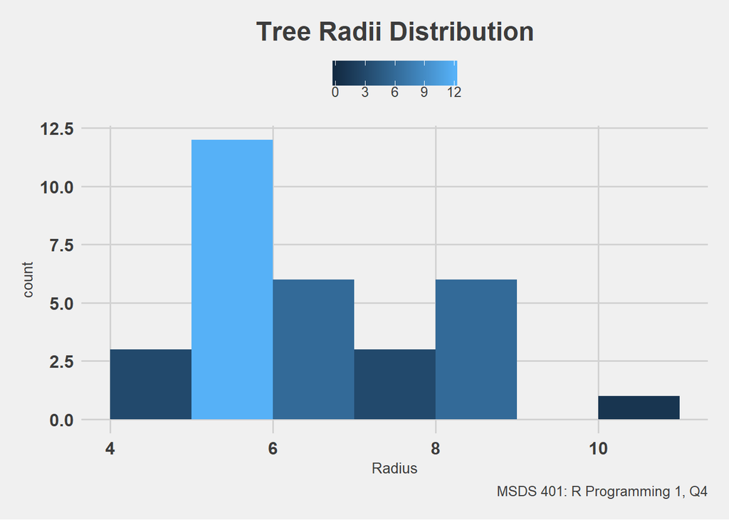

```r
ggplot(trees, aes(Radius, fill = ..count..)) +
    geom_histogram(breaks = pretty(trees$Radius)) +
    labs(title = "Tree Radii Distribution",
       caption = "MSDS 401: R Programming 1, Q4")
```

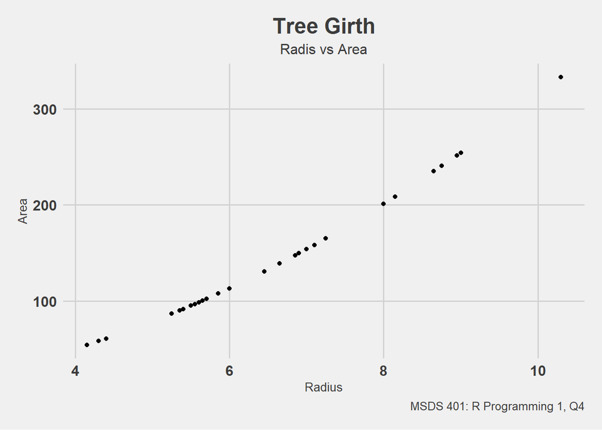

```r
ggplot(trees, aes(x = Radius, y = Area)) +
    geom_point() +
    labs(title = "Tree Girth",
        subtitle = "Radis vs Area",
       caption = "MSDS 401: R Programming 1, Q4")
```

### c.) Visualization

- Present a horizontal, notched, colored boxplot of the areas calculated in (b). Title and label the axis.

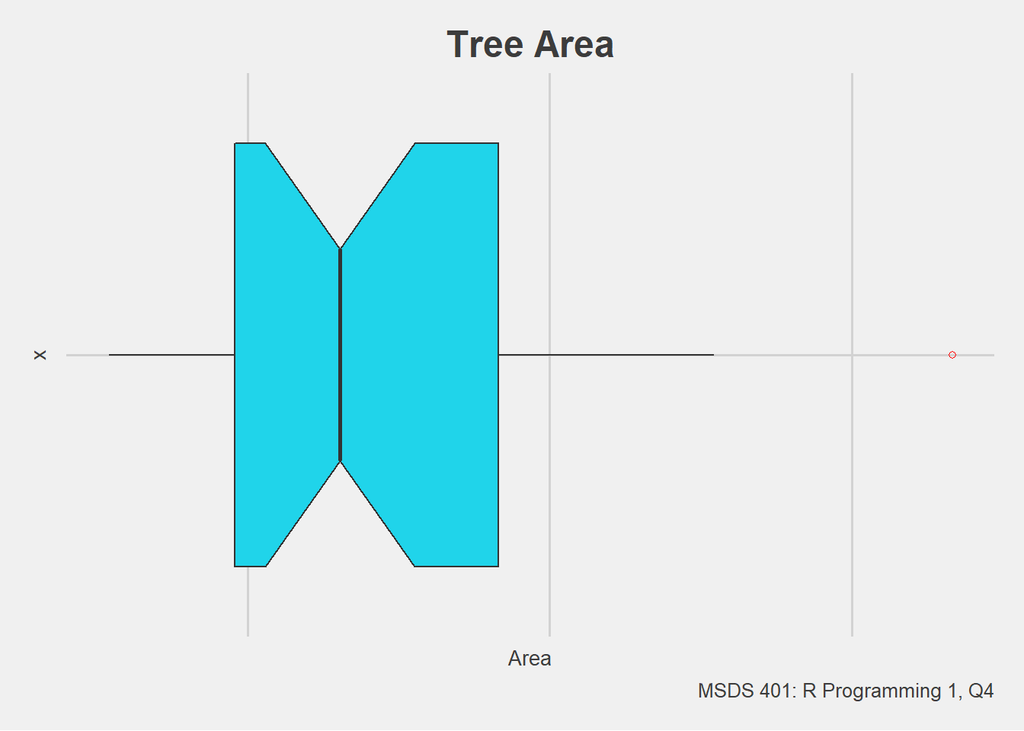

```r
ggplot(trees, aes( "", y = Area)) +
    geom_boxplot( outlier.colour = "red", fill = "#20D4EA", outlier.shape = 1, notch = T) +
    coord_flip() +
    labs(title = "Tree Area",
       caption = "MSDS 401: R Programming 1, Q4") +
    theme(axis.text.x = element_blank())
```

### d.) Statistical Test

- Demonstrate that the outlier revealed in the boxplot of Volume is not an extreme outlier.

*It is possible to do this with one line of code using *boxplot.stats()* or ‘manual’ calculation and logicals.*

- Identify the tree with the largest area and output on one line its row number and three measurements.

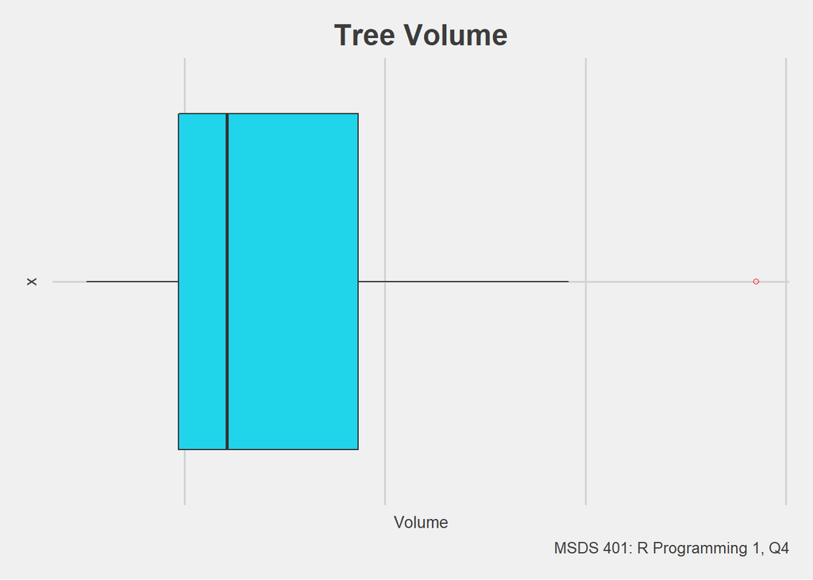

```r
ggplot(trees, aes("", y = Volume)) +
    geom_boxplot(outlier.colour = "red", outlier.shape = 1, fill = "#20D4EA") +
    coord_flip() +
    labs(title = "Tree Volume",
       caption = "MSDS 401: R Programming 1, Q4") +
    theme(axis.text.x = element_blank())
```

```r
# manual calculation:

ex_outlier_coef <- 3

q1 <- quantile(trees$Volume, .25)
q2 <- quantile(trees$Volume, .75)

ex_outlier_range <- q2 + ex_outlier_coef * (q2 - q1)

max_vol <- max(trees$Volume)

max_vol > ex_outlier_range # Not extreme.
```

```
##   75%
## FALSE
```

```r
# boxplot.stats method.

vol_extremes <- boxplot.stats(trees$Volume, coef = ex_outlier_coef)
vol_extremes$out # Not extreme.
```

```
## numeric(0)
```

```r
head(trees[order(-trees$Area)][, .(Row, Girth, Height, Volume)], 1) # 1 liner
```

| Row | Girth | Height | Volume |
| --- | --- | --- | --- |
| 31 | 20.6 | 87 | 77 |

## 5.) Exponential Distribution

(6 points) The exponential distribution is an example of a right-skewed distribution with outliers.  
This problem involves comparing it with a normal distribution which typically has very few outliers.

### a.) Distribution

- Use *set.seed(124)* and *rexp()* with n = 100, rate = 5.5 to generate a random sample designated as y.
- Generate a second random sample designated as x with *set.seed(127)* and *rnorm()* using n = 100, mean = 0 and sd = 0.15.
- Generate a new object using *cbind(x, y)*. **Do not output this object**; instead, assign it to a new name. Pass this object to *apply()* and compute the inter-quartile range (IQR) for each column: x and y.
- Use the function *IQR()* for this purpose. **Round the results to four decimal places and present** (this exercise shows the similarity of the IQR values.).

*For information about *rexp()*, use *help(rexp)* or *?rexp()*. **Do not output x or y.***

```r
set.seed(124)
y <- rexp(n = 100, rate = 5.5)

set.seed(127)
x <- rnorm(n = 100, mean = 0, sd = 0.15)

values <- cbind(x, y)

sapply(apply(values, 2, IQR), FUN = function(val) { round( val, 4 )})
```

```
##      x      y
## 0.2041 0.2164
```

### b.) Visualization

This item will illustrate the difference between a right-skewed distribution and a symmetric one.

- For base R plots, use *par(mfrow = c(2, 2))* to generate a display with four diagrams; *grid.arrange()* for ggplots.
- On the first row, for the normal results, present a histogram and a horizontal boxplot for x in color.
- For the exponential results, present a histogram and a horizontal boxplot for y in color.

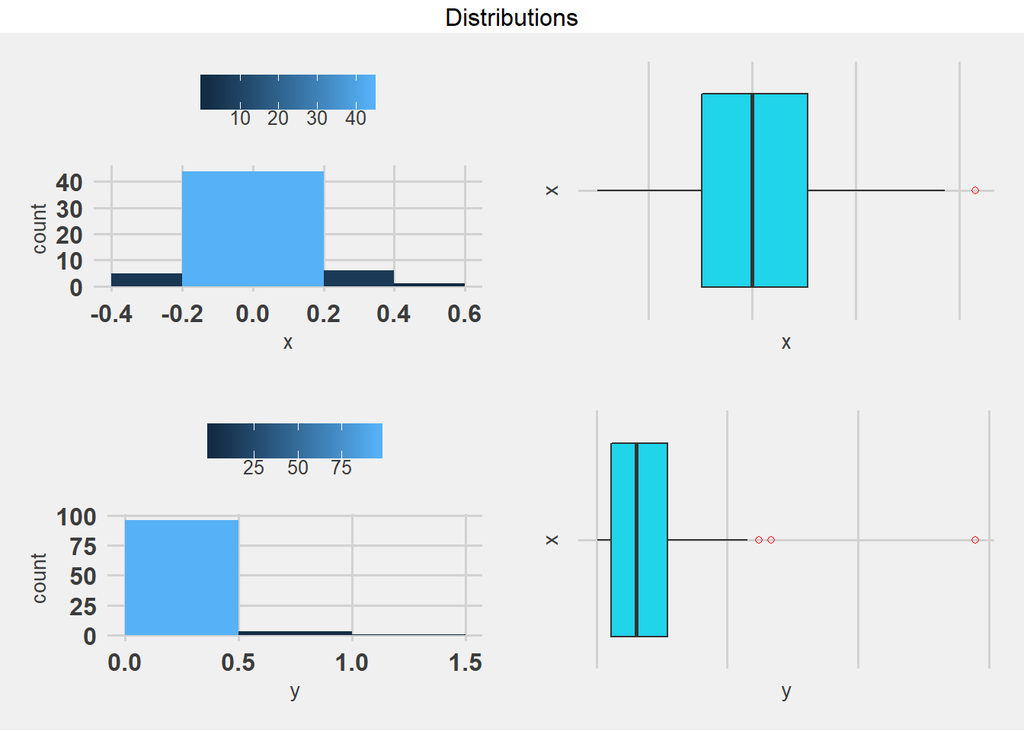

```r
values <- as.data.table(values)

p1 <- ggplot(values, aes(x = x, fill = ..count..)) +
    geom_histogram(breaks = pretty(values$x))

p2 <- ggplot(values, aes("", x)) +
    geom_boxplot(outlier.colour = "red", outlier.shape = 1, fill = "#20D4EA") +
    coord_flip() +
    theme(axis.text.x = element_blank())

p3 <- ggplot(values, aes(x = y, fill = ..count..)) +
    geom_histogram(breaks = pretty(values$y))

p4 <- ggplot(values, aes("", y)) +
    geom_boxplot(outlier.colour = "red", outlier.shape = 1, fill = "#20D4EA") +
    coord_flip() +
    theme(axis.text.x = element_blank())

grid.arrange(p1, p2, newpage = TRUE, p3, p4, top = "Distributions")
```

### c.) QQ-Plot

QQ plots are useful for detecting the presence of heavy-tailed distributions.

- Present side-by-side QQ plots, one for each sample, using *qqnorm()* and *qqline()*.
- Add color and titles. In base R plots, “cex” can be used to control the size of the plotted data points and text.
- Lastly, determine if there are any extreme outliers in either sample.

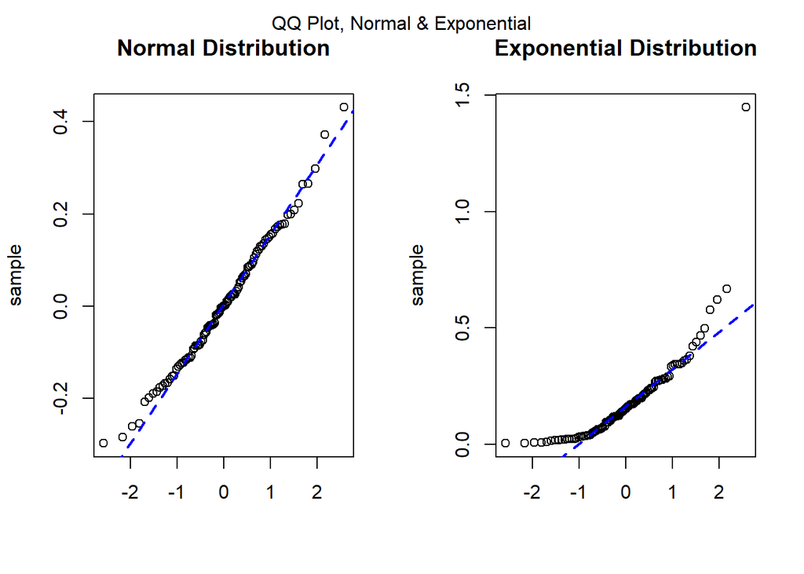

```r
# base R method. This is to ensure I followed instructions.

opar = par(mfrow = c(1, 2))

qqnorm(values$x, col = "black",  main = "Normal Distribution", xlab = "", ylab = "sample")
qqline(values$x, lty = 2, lwd = 2, col = "blue")

qqnorm(values$y, col = "black", main = "Exponential Distribution", xlab = "", ylab = "sample")
qqline(values$y, lty = 2, lwd = 2, col = "blue")

mtext("QQ Plot, Normal & Exponential", side = 3, line = -1.5, outer = TRUE)
```

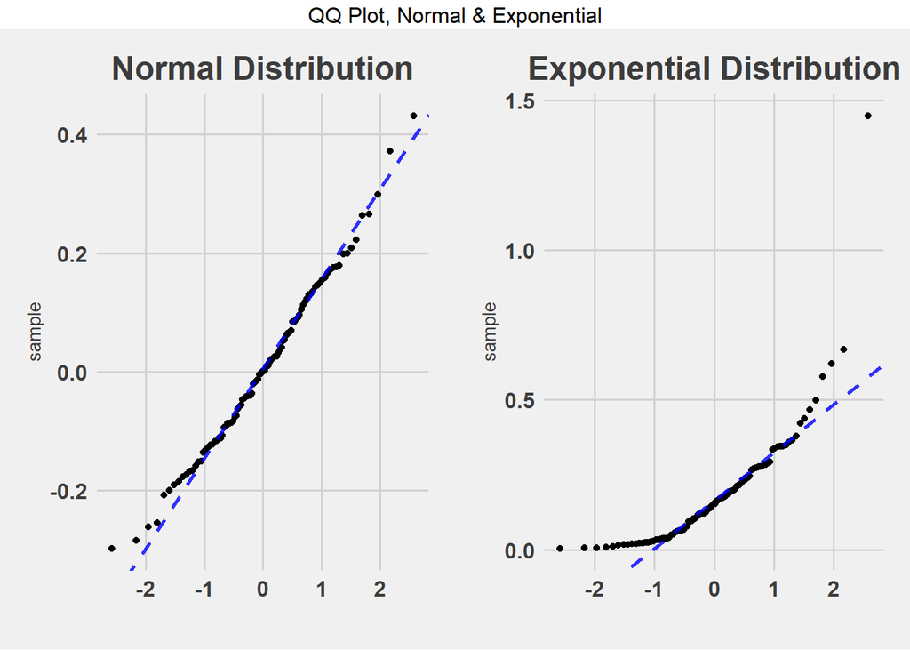

```r
par(opar)

# ggplot method, this is my perfered method which I believe to be identical.

#' Title
#' geom_qqline
#' @param data - vector of data used to generate line.
#' @param color - color of the qq line
#' @param line_width - width of the qq line
#' @param alpha - transparency of the qq line
#' @param line_type - qq line display type
#'
#' @return geom object that can be used in ggplot layering. This should be identical to the qqline in base R,
#' based upon by understanding of ?qqline
#' @export
#'
#' @examples see below:
geom_qqline <- function(data,
    color = "red", line_width = 1, alpha = 1, line_type = "dashed") {

    y <- quantile(data[!is.na(data)], c(0.25, 0.75))
    x <- qnorm(c(0.25, 0.75))

    # calculate slope and y-intercept
    slope <- diff(y) / diff(x)
    int <- first(y) - slope * first(x)

    # qq-line, in ggplot form.
  geom_abline(slope = slope, intercept = int, color = color, lwd = line_width, alpha = alpha, linetype = line_type)
}

q1 <- ggplot(values, aes(sample = x)) +
    stat_qq() +
    geom_qqline( values$x, color = "blue", alpha = .8 ) +
    labs(title = "Normal Distribution", x = "")

q2 <- ggplot(values, aes(sample = y)) +
    stat_qq() +
    geom_qqline( values$y, color = "blue", alpha = .8 ) +
    labs(title = "Exponential Distribution", x = "")

grid.arrange(q1, q2, ncol = 2, top = "QQ Plot, Normal & Exponential")
```

```r
# Detect any extreme outliers in x or y.
x_extremes <- boxplot.stats(values$x, coef = ex_outlier_coef) # no extreme outliers
x_extremes$out
```

```
## numeric(0)
```

```r
y_extremes <- boxplot.stats(values$y, coef = ex_outlier_coef) # 1 extreme outlier,
y_extremes$out
```

```
## [1] 1.448679
```